# R packages

April 29, 2019

## Introductions

- Graduate student in Biology - UF
- Quantitative community ecologist
- '#rstats' enthusiast
- This is my first presentation with R markdown
  - Resources to customize
  - I'd love some good/easy tutorials
  - It wasn't a fun experience
    - Building a package is definitely easier

Twitter and Github **@javirudolph**

## Why packages?

- To share
  - Easy to share a bundle
  - Code + data + documentation + tests
  - Anyone can download -> install -> use
- For you
  - Easy organization
    - set conventions make life easier
  - Documentation
    - can't remember what that function was for?
    - forces you to write documentation
  - Load a package and have functions easily accessible
    - Reduce your 'source()' lines

## Useful resources

- Hadley Wickham's [R packages](http://r-pkgs.org/)  
  - Second edition is in progress. Updates with `usethis`
- Emil Hvitfeldt's [blog post](https://www.hvitfeldt.me/blog/usethis-workflow-for-package-development/)
- [devtools](https://devtools.r-lib.org/)
- This tutorial/presentation: https://github.com/javirudolph/short-tutorials/

## Setup

We recommend using the RStudio IDE and start by installing these packages.

```r
install.packages(c("devtools", "roxygen2", "usethis"))
```

- **devtools** simplify package development - [cheatseet](https://www.rstudio.com/resources/cheatsheets/)
- **roxygen2** helps with the custom syntax used for package documentation
- **usethis** will set up components, directories, organize your package

```r
# load the libraries
library(devtools)
library(roxygen2)
library(usethis)
```

## Let's start!

Check your working directory, as this is were the package will be created.

```r
getwd()
```

You can change your working directory and specify it with `setwd()` or within the package building function:

```r
usethis::create_package("your path if not doing setwd/ your package name")
```

You don't need to set up a project or anything, `usethis` takes care of the setup.

After running the following line of code, you will have a new RStudio window open.

```r
usethis::create_package("rladiesgnv")
```

## create_package("your pkg name")

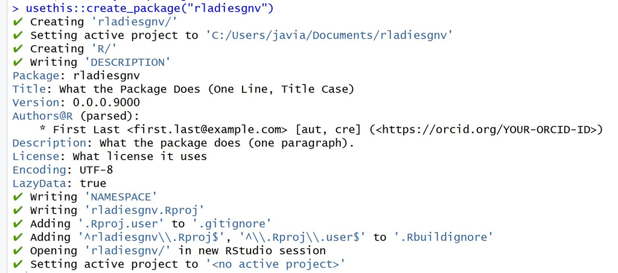

## Explore your new package

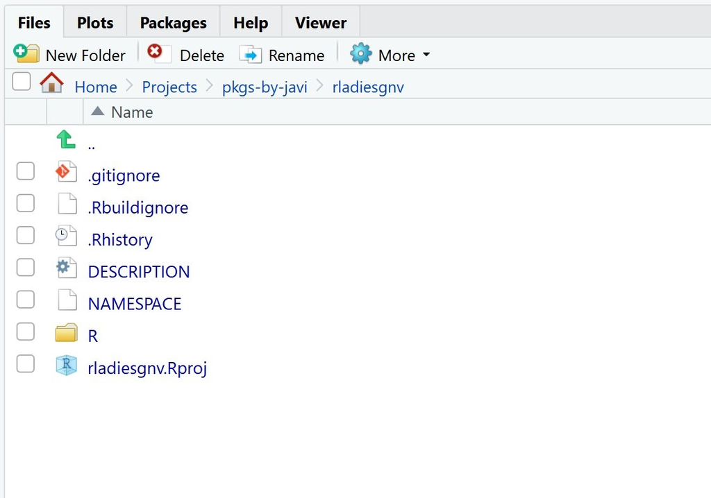

## Adding functions

After you've created the package, you will want to start adding some functions.

As an example we will do a simple function that returns the color palette for R Ladies.

The advantage of the package `usethis` is that as you edit certain files, it will make sure to keep everything connected and update any necessary files in other areas of the directory.

```r
library(usethis)

# Create the function file and edit
usethis::use_r("gimme_color_function")
```

## Adding functions continued…

You will notice that `use_r` automatically created the `.R` file for your function and placed it in the `R/` directory.

In the new script that opens, you can write your function.

In our case, the function let's us get the hex color codes for the R Ladies palette.

```r
gimme_color_codes <- function(wantAll = TRUE){
  hex_palette <- c("#181818", "#D3D3D3", "#88398A", "#FFFFF", "#562457")
  if(wantAll == TRUE){
    print(hex_palette)
  }
  else{
    print("You should go for all of them.")
  }
}
```

## You've got a package!

And you are done with our minimal package!

```r
# You can now press 'crt + shift + L'
# or

devtools::load_all()
```

This will 'build' and load the package. So you can test your new function by typing it in the console

```r
gimme_color_codes()
```

`[1] "#181818" "#D3D3D3" "#88398A" "#FFFFF" "#562457"`

## Documentation

The `roxygen2` package lets you write documentation in the same .R file where you've specified your function and then `devtools` generates the documentation.

You can write these comments before your function, which you can open using `use_r("gimme_color_function")` and start typing the comments with `#'`.

```r
#' @title RLadies palette function
#'
#' @description This function will print out the hex codes for the RLadies palette
#' @param wantALL Do you want all the colors available in this palette? The default is TRUE
#' @keywords RLadies colors
#' @export
#' @examples
#' gimme_color_codes()
#'
```

## Documentation

Then type `devtools::document()` in the console, so it generates the documentation (`.Rd` files in the `man/` directory). More info [here](http://r-pkgs.had.co.nz/man.html)

.  
Open the `NAMESPACE` to check out the changes.

Now, in the console:

```r
# 'ctrl + shift + b' or
devtools::install()

# search for your function
?gimme_color_codes()
```

## Documentation

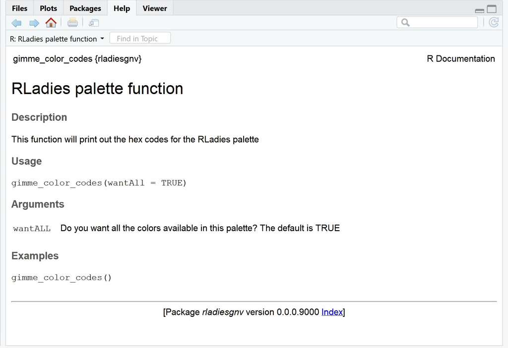

## Package documentation

We have edited the documentation for the function, but not for the overall package.  
To do that:

```r
usethis::use_package_doc()
```

It will create an `.R` file used by `devtools` to create package documentation once we type `devtools::document()` in the console.

When we check our package documentation:

```r
# 'ctrl + shift + b' or
devtools::install()

?rladiesgnv
```

## Package documentation

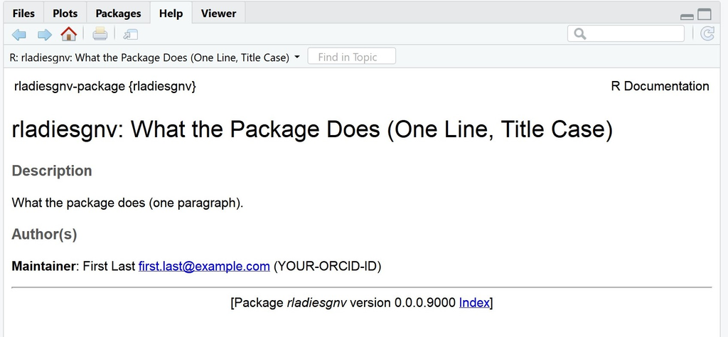

## We should edit the package description

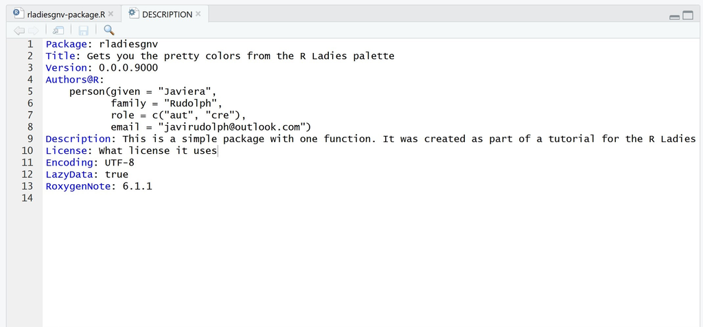

## cont…

```r
devtools::document()
devtools::install()
?rladiesgnv
```

and we can also add a license:

```r
usethis::use_mit_license("Your Name Here")
```

## …

Or link for version control and publish to Github:

```r
usethis::use_git()
usethis::use_github()
```

If you get an error with that last line, you probably haven't created an authorization token from Github:

```r
usethis::browse_github_pat()
usethis::use_github(protocol = "https",
                    auth_token = "the token number you get from the Github site")
```

## Last, but not least

Once you publish your package to github, you can create a `README` that will let your users know what this repo is all about.

```r
usethis::use_readme_rmd()
```

check out this package at: https://github.com/javirudolph/rladiesgnv and even install it.

```r
# In a new RStudio session:
library(devtools)
devtools::install_github("javirudolph/rladiesgnv")
```

## Thank you!

[figure not shown]

.

You can follow me on twitter or github **@javirudolph**

Email: javirudolph@outlook.com